# Apple firmness — vibration-trace processing pipeline

2026-05-10

## Background

Portfolio piece — a synthetic recreation of a non-destructive **vibration-based firmness** measurement workflow I built during a fruit-quality project. The original recordings are not shareable, so this repo simulates qualitatively similar two-channel waveforms (stem end and calyx end), recovers the characteristic minimum from each trace, extracts its time `t_min`, and looks at the joint `(CH1 t_min, CH2 t_min)` distribution.

The pipeline reproduces the four steps I used in practice:

1. acquire two-channel time-series per fruit;
2. detect the diagnostic minimum on each channel;
3. plot every trace with a coloured marker at the detected minimum for visual QA;
4. summarise the dataset as a `CH1` × `CH2` scatter coloured by trial.

## Simulated data

```r
source("R/simulate.R")
```

```r
source("R/process.R")
traces <- readRDS("data/traces.rds")
n_fruit <- length(unique(traces$fruit))
n_trial <- length(unique(traces$trial))
sprintf("%d fruits across %d trials, %d samples per trace.",
        n_fruit, n_trial, sum(traces$fruit == 1))
```

```
## [1] "104 fruits across 13 trials, 101 samples per trace."
```

## Example traces with detected minima

Vertical bars mark the detected minimum on each channel (orange = CH1, green = CH2).

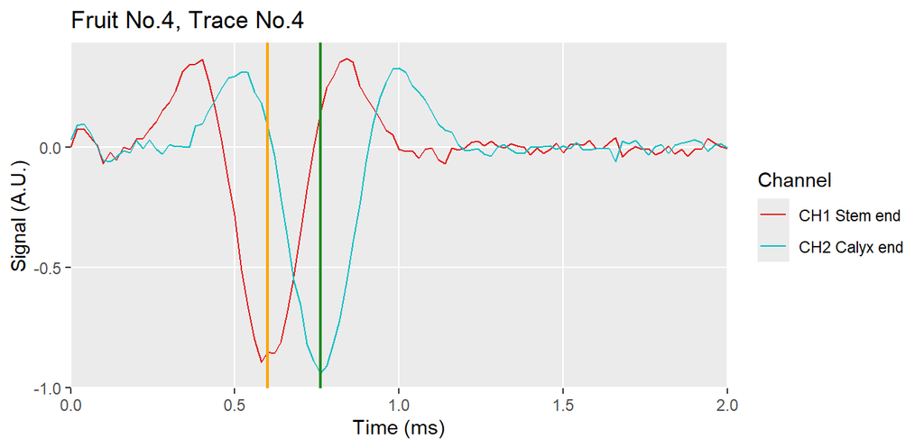

```r
plot_trace(traces, fruit_id = 4)
```

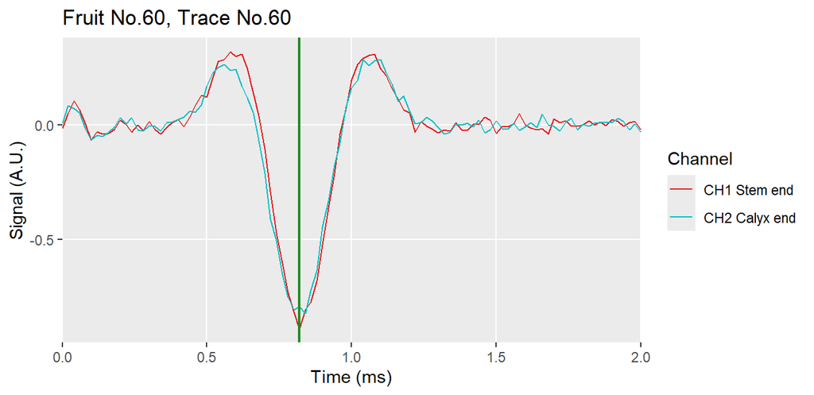

```r
plot_trace(traces, fruit_id = 60)
```

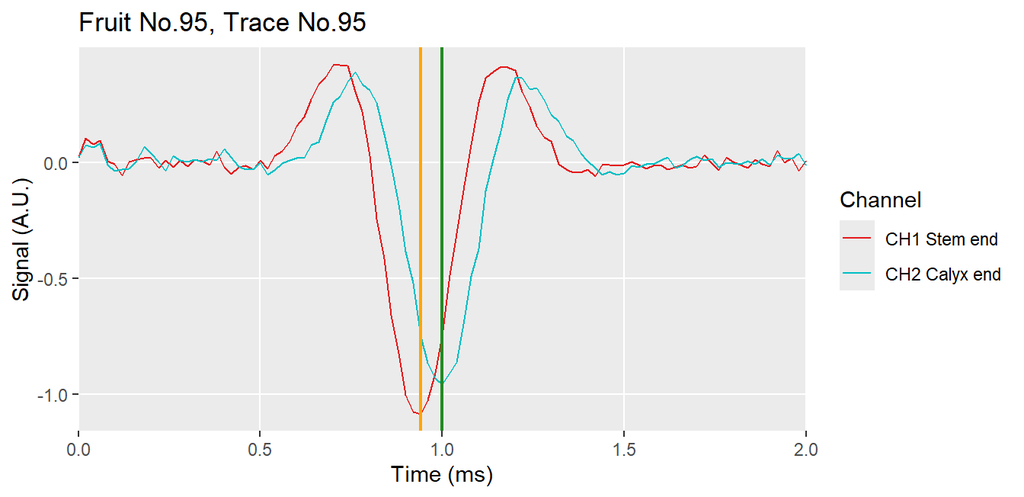

```r
plot_trace(traces, fruit_id = 95)
```

A larger PNG gallery is rendered by `R/batch_plots.R` into `figures/traces/`.

## Per-fruit summary

```r
summary_df <- summarise_traces(traces)
head(summary_df)
```

```
## # A tibble: 6 × 6
##   trial  trial_no fruit channel t_min_ms  y_min
##   <fct>     <int> <int> <chr>      <dbl>  <dbl>
## 1 Sep-24        1     1 CH1         0.54 -0.916
## 2 Sep-24        1     1 CH2         0.56 -0.978
## 3 Sep-24        1     2 CH1         0.56 -0.985
## 4 Sep-24        1     2 CH2         0.62 -0.825
## 5 Sep-24        1     3 CH1         0.54 -1.00
## 6 Sep-24        1     3 CH2         0.56 -0.924
```

```r
summary_wide <- tidyr::pivot_wider(summary_df,
                                   id_cols = c(trial, trial_no, fruit),
                                   names_from = channel,
                                   values_from = t_min_ms)
```

## CH1 vs CH2 scatter (pattern detection)

Each point is one fruit. Most points sit near the CH1 = CH2 diagonal; vertical excursions are CH2-only outliers (skin defect on the calyx end of the fruit, in the original interpretation).

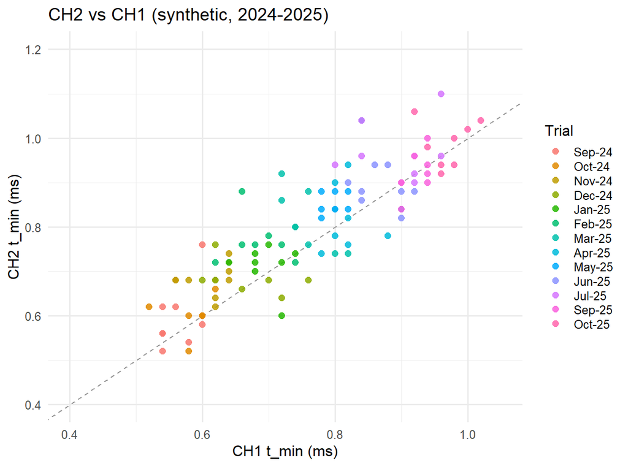

```r
library(ggplot2)
ggplot(summary_wide, aes(CH1, CH2, colour = trial)) +
  geom_abline(slope = 1, intercept = 0, linetype = "dashed",
              colour = "grey60") +
  geom_point(size = 2.2, alpha = 0.85) +
  scale_x_continuous(limits = c(0.4, 1.05)) +
  scale_y_continuous(limits = c(0.4, 1.20)) +
  labs(title = "CH2 vs CH1 (synthetic, 2024-2025)",
       x = "CH1 t_min (ms)",
       y = "CH2 t_min (ms)",
       colour = "Trial") +
  theme_minimal(base_size = 12) +
  theme(legend.key.height = unit(0.8, "lines"))
```

```r
ggsave("figures/scatter_ch1_ch2.png", width = 7, height = 5.2, dpi = 150)
```

## SS1 — CH2 vs CH1 with continuous t_min gradient

Same scatter as above but coloured by the **mean t_min** across the two channels — a purely geometric ranking that highlights the diagonal trend without claiming any biophysical firmness model. Earlier minima cluster in the lower-left (purple/blue); later minima in the upper-right (orange/red).

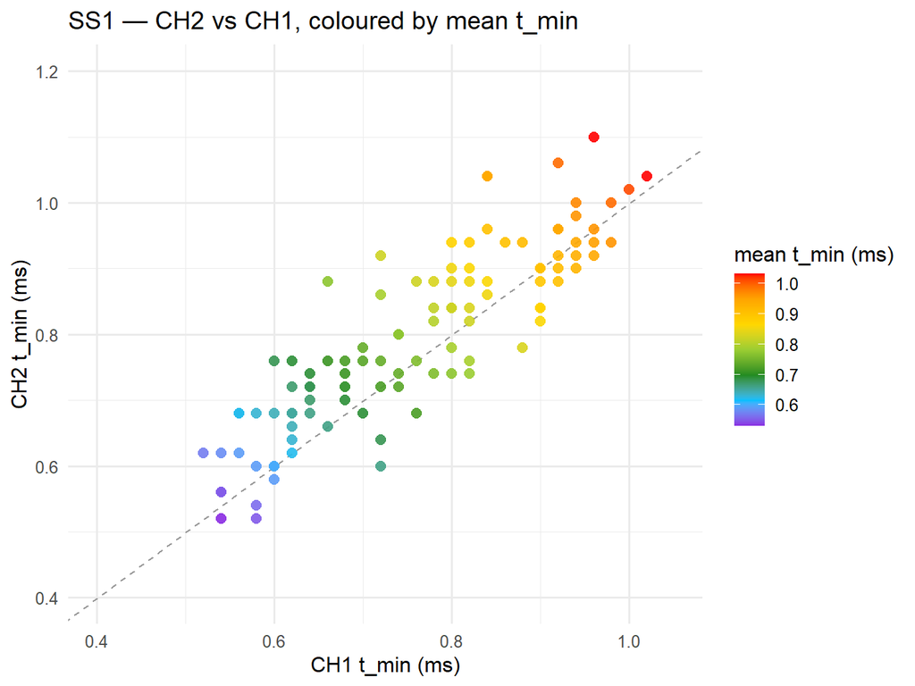

```r
summary_wide$t_min_mean <- (summary_wide$CH1 + summary_wide$CH2) / 2

ss1_palette <- c("blueviolet", "deepskyblue", "forestgreen",
                 "yellowgreen", "gold", "orange", "red")

ggplot(summary_wide, aes(CH1, CH2, colour = t_min_mean)) +
  geom_abline(slope = 1, intercept = 0, linetype = "dashed",
              colour = "grey60") +
  geom_point(size = 2.4, alpha = 0.9) +
  scale_x_continuous(limits = c(0.4, 1.05)) +
  scale_y_continuous(limits = c(0.4, 1.20)) +
  scale_colour_gradientn(colours = ss1_palette) +
  labs(title = "SS1 — CH2 vs CH1, coloured by mean t_min",
       x = "CH1 t_min (ms)",
       y = "CH2 t_min (ms)",
       colour = "mean t_min (ms)") +
  theme_minimal(base_size = 12) +
  theme(legend.key.height = unit(1.2, "lines"))
```

```r
ggsave("figures/ss1_firmness.png", width = 7.2, height = 5.4, dpi = 150)
```

Off-diagonal points indicate asymmetry between stem-end and calyx-end response on the same fruit.

## Disclaimer

Traces are simulated with a damped Gabor wavelet plus a small initial transient and Gaussian noise. The repo demonstrates **the processing pipeline**, not a biological finding.